# Final Project 204881403-204865687

Saar Ofek and Michal Mano

2023-02-07

#### Abstract:

Asthma is a chronic inflammatory disease that affects the lungs and is typically characterized by shortness of breath, wheezing and coughing. Worldwide it affects some 300 million people. Symptom onset can occur at any time during childhood or adulthood. There are varying degrees of asthma from mild cases that require little to no treatment, to severe cases that require long-term use of medication and can be life threatening. There are many factors that are known to affect asthma severity including but not limited to obesity, allergies, and exposure to pollutants, such as in urban areas. It is also known that asthma is more likely among family members, suggesting a genetic link for the disease that is not yet well defined. Our study aims to explore the genetic basis for asthma severity in order to characterize the differences between those affected by mild asthma and those with more severe cases. We used bulk RNA-seq data sets from patients with varying degrees of asthma severity and performed differential expression analysis. Our analysis did not find many differentially expressed genes in those with severe asthma and mild/moderate asthma, however there were a few genes that were upregulated in severe asthma: CYP1B1, LAMA4, and FLNC. Interestingly, there was not a significant difference in expression of these genes between healthy people and mild/moderate cases, suggesting they are unique to severe asthma. In addition, we performed a GWAS analysis and found that many SNPs are associated with asthma in general, and there are certain genes that are more strongly associated with different ages of onset. In conclusion, We found certain genetic differences between mild/moderate asthma and severe asthma. These could be targets for therapies or identification of individuals who are at higher risk of developing asthma related complications.

```r
library(tidyverse, quietly = T)
library(DESeq2, quietly = T)
library(GEOquery, quietly = T)
library(AnnotationDbi)
library(org.Hs.eg.db)
library(EnhancedVolcano)
library(msigdbr)
library(clusterProfiler)
library(fastman)
```

## FIRST ANALYSIS: Bulk RNA DESeq

We chose to perform the same DESeq analysis on two different bulk RNA data sets.  
The first dataset was obtained from 39 patients: 17 with mild/moderate asthma, 6 healthy, 16 severe.  
The samples were obtained by bronchoalveolar lavage and thus contain cells from the lungs.  
Dataset: https://www.ncbi.nlm.nih.gov/geo/query/acc.cgi?acc=GSE136587

```r
counts <- read.table("./Bulk Data sets/GSE136587_IMSA_BAL_RAW_Counts.txt.gz", header = T, check.names = FALSE, skip = 1)
counts
#shorten the column names to be just the sample name without BAL_# at the end, in order to match the metadata
long_names <- colnames(counts)
colnames(counts) <- lapply(X=strsplit(x=long_names, split="_"), FUN=function(x) paste0(head(x, n=1), collapse = "_"))
counts
gse <- getGEO(filename="./Bulk Data sets/GSE136587_series_matrix.txt")
metadata <- as_tibble(gse)
metadata
```

Now, we chose columns that could be pertinent to our analysis, and clean them up. Sample, severity, gender, steroid treatment, and age

```r
metadata <- metadata %>%
  dplyr::select(sample = title, severity = characteristics_ch1.1, gender = characteristics_ch1.2, age = characteristics_ch1.3, steroids = characteristics_ch1.4)
metadata
```

```
## # A tibble: 39 × 5
##    sample  severity                     gender         age     steroids
##    <chr>   <chr>                        <chr>          <chr>   <chr>
##  1 IMSA008 asthma degree: mild/moderate gender: male   age: 26 "steroid: no"
##  2 IMSA010 asthma degree: mild/moderate gender: male   age: 28 ""
##  3 IMSA011 asthma degree: mild/moderate gender: female age: 56 "steroid: yes"
##  4 IMSA013 asthma degree: severe        gender: male   age: 43 "steroid: yes"
##  5 IMSA017 asthma degree: mild/moderate gender: female age: 54 "steroid: yes"
##  6 IMSA020 asthma degree: healthy       gender: female age: 27 "steroid: no"
##  7 IMSA022 asthma degree: mild/moderate gender: male   age: 29 "steroid: yes"
##  8 IMSA023 asthma degree: mild/moderate gender: female age: 27 "steroid: no"
##  9 IMSA026 asthma degree: severe        gender: male   age: 31 "steroid: yes"
## 10 IMSA027 asthma degree: severe        gender: female age: 51 "steroid: yes"
## # … with 29 more rows
```

```r
# remove prefixes from data and remove a sample that doesn't have info on steroid use
metadata <- metadata[!metadata$steroids == "",]
metadata$gender <- gsub("gender: ","", metadata$gender)
metadata$age <- gsub("age: ", "", metadata$age)
metadata$steroids <-gsub("steroid: ","", metadata$steroids)
metadata$severity <- gsub("asthma degree: ","", metadata$severity)
metadata
```

```
## # A tibble: 38 × 5
##    sample  severity      gender age   steroids
##    <chr>   <chr>         <chr>  <chr> <chr>
##  1 IMSA008 mild/moderate male   26    no
##  2 IMSA011 mild/moderate female 56    yes
##  3 IMSA013 severe        male   43    yes
##  4 IMSA017 mild/moderate female 54    yes
##  5 IMSA020 healthy       female 27    no
##  6 IMSA022 mild/moderate male   29    yes
##  7 IMSA023 mild/moderate female 27    no
##  8 IMSA026 severe        male   31    yes
##  9 IMSA027 severe        female 51    yes
## 10 IMSA028 mild/moderate female 52    yes
## # … with 28 more rows
```

Next we reorder columns in counts so that it lines up with the metadata, and set disease severity as factor

```r
counts <- cbind(GeneID = counts$GeneID, counts[,metadata$sample])
all(metadata$sample == colnames(counts)[-1])
```

```
## [1] TRUE
```

```r
metadata <- mutate(metadata, severity = as.factor(severity))
metadata$severity
```

```
##  [1] mild/moderate mild/moderate severe        mild/moderate healthy
##  [6] mild/moderate mild/moderate severe        severe        mild/moderate
## [11] severe        mild/moderate severe        mild/moderate mild/moderate
## [16] severe        mild/moderate severe        severe        mild/moderate
## [21] mild/moderate severe        healthy       healthy       severe
## [26] mild/moderate severe        mild/moderate severe        healthy
## [31] severe        mild/moderate mild/moderate healthy       severe
## [36] healthy       severe        severe
## Levels: healthy mild/moderate severe
```

Now our data is preprocessed and is ready to be analyzed with DESeq. Here, we compare mild/moderate asthma with severe asthma patients in an attempt to determine if there are differentially expressed genes.

```r
dds <- DESeqDataSetFromMatrix(countData=counts,
                              colData=metadata,
                              design= ~ steroids + gender + severity,
                              tidy=TRUE)
dds$severity <- relevel(dds$severity, "severe")
dds <- DESeq(dds)
resultsNames(dds)
res <- results(dds)
summary(res)
resLFC <- lfcShrink(dds, coef="severity_mild.moderate_vs_severe", type="apeglm")
resOrdered <- resLFC[order(resLFC$pvalue),]
resOrdered
write.csv(resOrdered, "signif_results.csv")
```

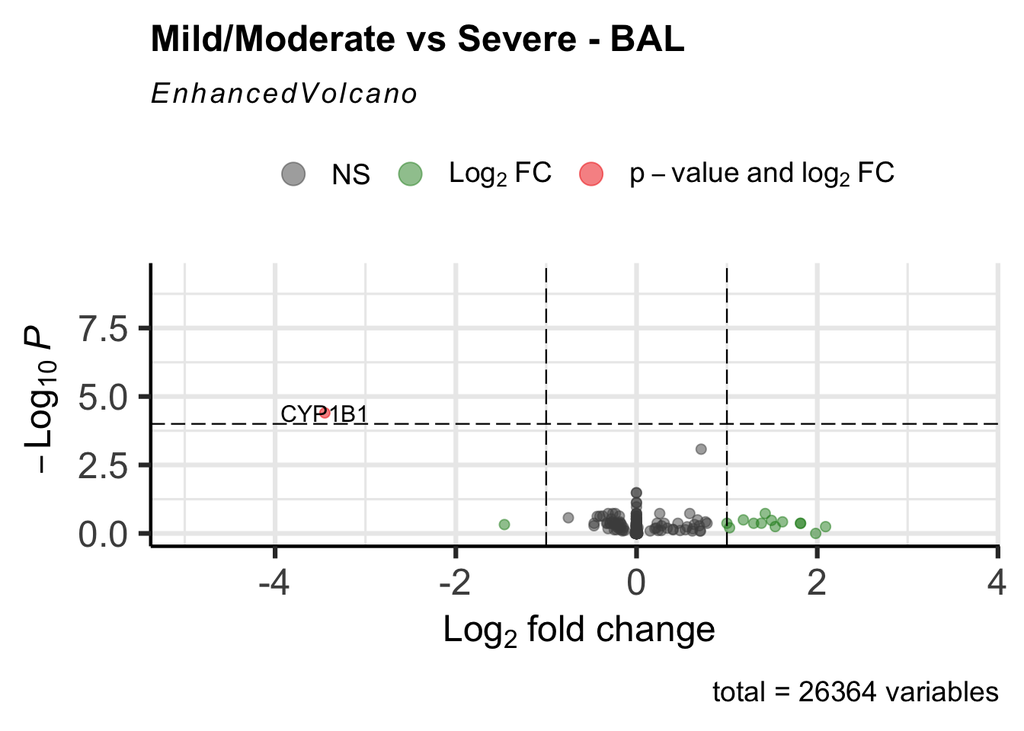

```r
EnhancedVolcano(resOrdered,
                lab = rownames(resOrdered),
                x = 'log2FoldChange',
                y = 'padj',
                labSize = 4, title = 'Mild/Moderate vs Severe - BAL',
                pCutoff = 10e-5)
```

We will take a closer look at the gene CYP1B1.

```r
i <- which(rownames(resOrdered)=='CYP1B1')
resOrdered[i,]
```

```
## log2 fold change (MAP): severity mild.moderate vs severe
## Wald test p-value: severity mild.moderate vs severe
## DataFrame with 1 row and 5 columns
##         baseMean log2FoldChange     lfcSE      pvalue        padj
##        <numeric>      <numeric> <numeric>   <numeric>   <numeric>
## CYP1B1   97.4796       -3.44981  0.629192 1.76668e-09 3.97167e-05
```

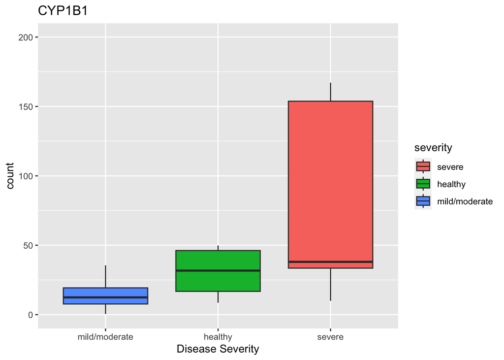

```r
d <- plotCounts(dds, gene=rownames(resOrdered)[i], intgroup="severity", returnData=TRUE)
ggplot(d, aes(x = reorder(severity, count, FUN=median), y = count)) +
  geom_boxplot(aes(fill=severity)) +
  ggtitle("CYP1B1") +
  coord_cartesian(ylim = c(0,200)) +
  xlab("Disease Severity")
```

### Additional DESeq analysis on another data set.

```r
counts_BEC <- read.table("./Bulk Data sets/GSE158752_IMSA_BEC-RAW_Counts.txt.gz", header = T, check.names = FALSE)
counts_BEC
#here we won't shorten the names because it already matches the metadata
gse <- getGEO(filename="./Bulk Data sets/GSE158752_series_matrix.txt")
metadata_BEC <- as_tibble(gse)
metadata_BEC
```

We select the same characteristics as the previous dataset and clean it up.

```r
metadata_BEC <- metadata_BEC %>%
  dplyr::select(sample = title, severity = characteristics_ch1.2, gender = characteristics_ch1.4, age = characteristics_ch1.6, steroids = characteristics_ch1.3)
metadata_BEC
```

```
## # A tibble: 67 × 5
##    sample        severity                   gender         age     steroids
##    <chr>         <chr>                      <chr>          <chr>   <chr>
##  1 IMSA001_EPI_H diagnosis: Healthy Control gender: male   age: 31 steroid: no
##  2 IMSA002_EPI_H diagnosis: Healthy Control gender: female age: 35 steroid: no
##  3 IMSA004_EPI_S diagnosis: Severe Asthma   gender: female age: 56 steroid: yes
##  4 IMSA005_EPI_M diagnosis: M/M Asthma      gender: female age: 27 steroid: no
##  5 IMSA006_EPI_M diagnosis: M/M Asthma      gender: female age: 33 steroid: yes
##  6 IMSA007_EPI_S diagnosis: Severe Asthma   gender: female age: 34 steroid: yes
##  7 IMSA008_EPI_M diagnosis: M/M Asthma      gender: male   age: 26 steroid: no
##  8 IMSA010_EPI_M diagnosis: M/M Asthma      gender: male   age: 28 steroid: n
##  9 IMSA011_EPI_M diagnosis: M/M Asthma      gender: female age: 56 steroid: yes
## 10 IMSA012_EPI_H diagnosis: Healthy Control gender: female age: 24 steroid: no
## # … with 57 more rows
```

```r
metadata_BEC$gender <- gsub("gender: ","", metadata_BEC$gender)
metadata_BEC$age <- gsub("age: ", "", metadata_BEC$age)
metadata_BEC$steroids <- gsub("steroid: ","", metadata_BEC$steroids)
metadata_BEC$severity <- gsub("diagnosis: ","", metadata_BEC$severity)

#one sample has "steroid:n instead of the full word "no".
metadata_BEC <- metadata_BEC %>%
  mutate(steroids = str_replace(steroids, "no", "n")) %>%
  mutate(steroids = str_replace(steroids, "n", "no"))
metadata_BEC
```

```
## # A tibble: 67 × 5
##    sample        severity        gender age   steroids
##    <chr>         <chr>           <chr>  <chr> <chr>
##  1 IMSA001_EPI_H Healthy Control male   31    no
##  2 IMSA002_EPI_H Healthy Control female 35    no
##  3 IMSA004_EPI_S Severe Asthma   female 56    yes
##  4 IMSA005_EPI_M M/M Asthma      female 27    no
##  5 IMSA006_EPI_M M/M Asthma      female 33    yes
##  6 IMSA007_EPI_S Severe Asthma   female 34    yes
##  7 IMSA008_EPI_M M/M Asthma      male   26    no
##  8 IMSA010_EPI_M M/M Asthma      male   28    no
##  9 IMSA011_EPI_M M/M Asthma      female 56    yes
## 10 IMSA012_EPI_H Healthy Control female 24    no
## # … with 57 more rows
```

The data in counts is already lined up with the metadata.

```r
all(metadata_BEC$sample == colnames(counts_BEC)[-1])
```

```
## [1] TRUE
```

```r
metadata_BEC <- mutate(metadata_BEC, severity = as.factor(severity))

metadata_BEC$severity
```

```
##  [1] Healthy Control Healthy Control Severe Asthma   M/M Asthma
##  [5] M/M Asthma      Severe Asthma   M/M Asthma      M/M Asthma
##  [9] M/M Asthma      Healthy Control Severe Asthma   M/M Asthma
## [13] M/M Asthma      Healthy Control Healthy Control M/M Asthma
## [17] M/M Asthma      Severe Asthma   Severe Asthma   M/M Asthma
## [21] Severe Asthma   M/M Asthma      Severe Asthma   M/M Asthma
## [25] Severe Asthma   M/M Asthma      Severe Asthma   M/M Asthma
## [29] M/M Asthma      Severe Asthma   Severe Asthma   M/M Asthma
## [33] M/M Asthma      Severe Asthma   Healthy Control M/M Asthma
## [37] Healthy Control M/M Asthma      Severe Asthma   Severe Asthma
## [41] M/M Asthma      M/M Asthma      M/M Asthma      Severe Asthma
## [45] M/M Asthma      Severe Asthma   Healthy Control Severe Asthma
## [49] M/M Asthma      M/M Asthma      Severe Asthma   Healthy Control
## [53] Severe Asthma   Severe Asthma   Healthy Control Severe Asthma
## [57] Severe Asthma   Severe Asthma   Healthy Control Healthy Control
## [61] Healthy Control Severe Asthma   Healthy Control Healthy Control
## [65] Healthy Control Severe Asthma   Healthy Control
## Levels: Healthy Control M/M Asthma Severe Asthma
```

Again, we compare Mild/Moderate asthma with severe asthma.

```r
dds_BEC <- DESeqDataSetFromMatrix(countData=counts_BEC,
                              colData=metadata_BEC,
                              design= ~gender + steroids + severity,
                              tidy=TRUE)
dds_BEC$severity <-relevel(dds_BEC$severity, "Severe Asthma")
dds_BEC <-DESeq(dds_BEC)
res_BEC <- results(dds_BEC)
resultsNames(dds_BEC)
summary(res_BEC)
resLFC_BEC <- lfcShrink(dds_BEC, coef="severity_M.M.Asthma_vs_Severe.Asthma", type="apeglm")

resOrdered_BEC <- resLFC_BEC[order(resLFC_BEC$pvalue),]
resOrdered_BEC
write.csv(resOrdered_BEC, "signif_results_BEC.csv")
```

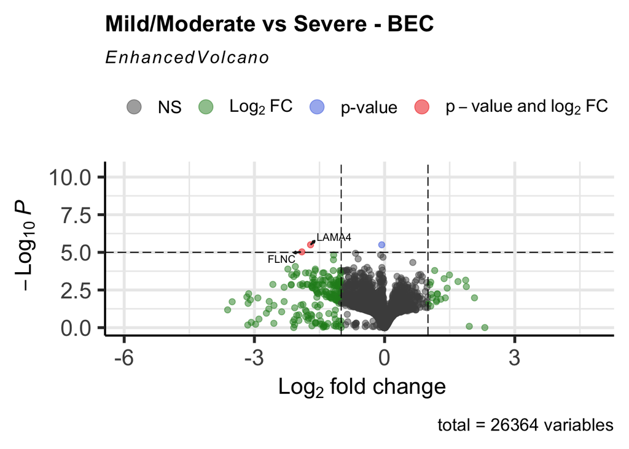

```r
EnhancedVolcano(resOrdered_BEC,
                lab = rownames(resOrdered_BEC),
                x = 'log2FoldChange',
                y = 'padj',
                title = 'Mild/Moderate vs Severe - BEC',
                labSize = 3,drawConnectors = TRUE,
                widthConnectors = 0.75,
                )
```

This volcano plot gave us two significant genes. LAMA4 and FLNC. We’ll make a boxplot for each.

```r
i <- which(rownames(resOrdered_BEC)=='LAMA4')
resOrdered_BEC[i,]
```

```
## log2 fold change (MAP): severity M.M.Asthma vs Severe.Asthma
## Wald test p-value: severity M.M.Asthma vs Severe.Asthma
## DataFrame with 1 row and 5 columns
##        baseMean log2FoldChange     lfcSE      pvalue       padj
##       <numeric>      <numeric> <numeric>   <numeric>  <numeric>
## LAMA4   49.2851       -1.70659  0.290489 1.62836e-10 3.1581e-06
```